# Exploratory Analysis: the Opioid Crisis and its relationship with the Pharmaceutical Industry

Team 2 INFO 478

2/22/2022

> For our population health informatics project, our group will be focusing on the second wave of the United States opioid epidemic (starting around 2010). The first wave of the opiod crisis began in the mid-1990’s when the pharmacutical drug OxyContin was developed and mass produced by Purdue Pharma, and the second wave began roughly in 2010 and lasted for a few years. The mortality of the second wave is intensified due to the growing heroin market which attracted populations who were already addicted to perscription opioids in addition to those who developed a prescription drug addiction. Most recently, starting in 2018, the United States has begun to see a third wave with deaths surging from synthetic opioids like fentanyl entering the illegal drug market. With our focus being the second wave, our variable of interest is the financial success of major US pharmacutica companies who, under minimal regulations, contributed to the severity of the epidemic. The health metric that we will use for our visualizations will be mortality (sum of all opioid related deaths in a calendar year in the US). The opioid epidemic is not only a serious public heath crisis, but is also extremely damaging to the US economy, with $78.5 billion in losses each year due to lost productivity, addiction treatment, and criminal justice involvement.

## Visualization of Opioid Related Deaths and State Household Income

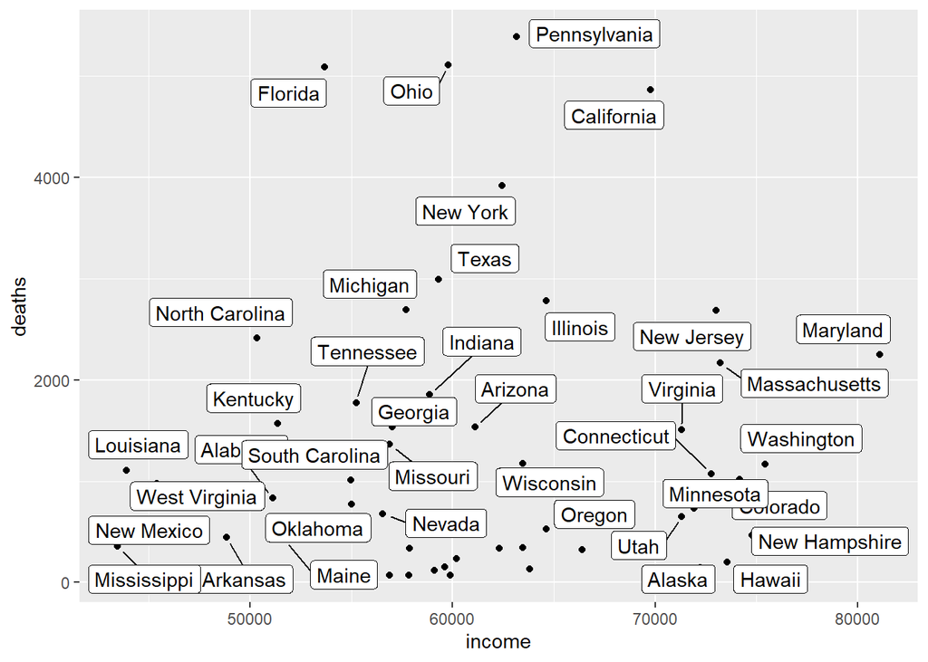

> From the scatterplot given above, the trend between total number of opioid related-deaths and average household income can be explored across different states in 2017. The states with the highest average household incomes are Maryland, Washington, and New Hampshire, and the states with the highest number of opioid deaths are Pennsylvania, Ohio, and Florida. Those with the lowest average household incomes are Mississippi, Louisiana, and West Virginia, and those with the lowest number of opioid deaths are North Dakota, Wyoming, and South Dakota. From these data points alone, there seems to be no direct correlation between average household income and opiod deaths. However, there could be other overarching correlations in the data that skew the trend. For instance, the scatter plot charts the relationship using the total number of opioid-related deaths, not the standardized rate of deaths per population size. By plotting deaths using the total number metric instead of a rate, the visualization allows for the possibility of other trends that cannot be attributed to household income. Two states that we will examine more closely are Maryland and Massachusetts, since these states have higher incomes and a high amount of overdose deaths.